# Assignment4-2

HsiungYi

13 October 2019

#Finding1

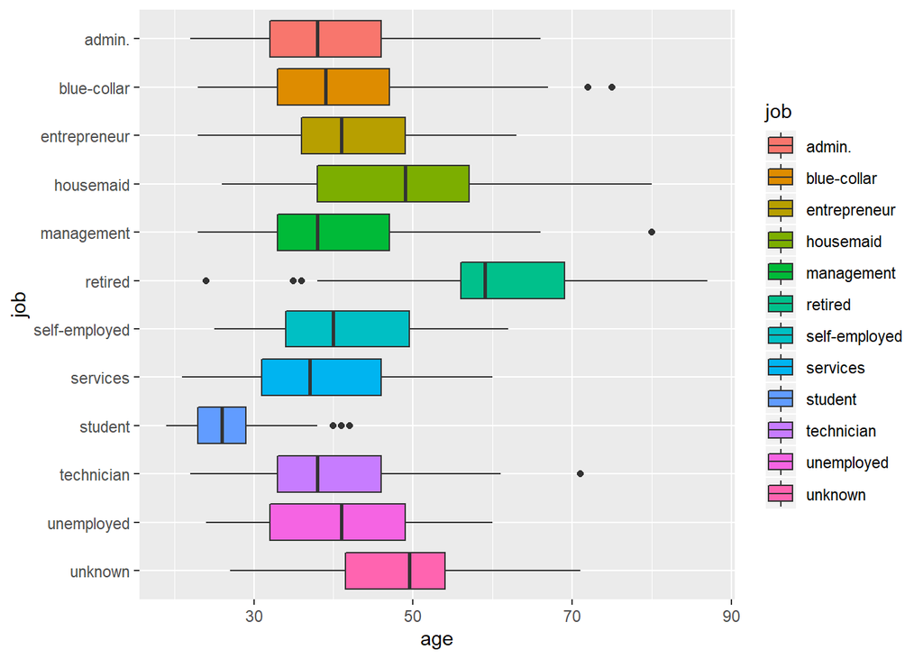

```r
ggplot(bank, aes(job, age, fill = job)) +
  geom_boxplot()+
  coord_flip()+
  scale_x_discrete(limit = rev(levels(bank$job)))
```

*From this boxplot, we can observe that people who are already retired are most between 50s to 70s.* It make sense unless you are “the second generation of the rich”, then you are retired when you were born, or most of the people have to work.

#Finding2

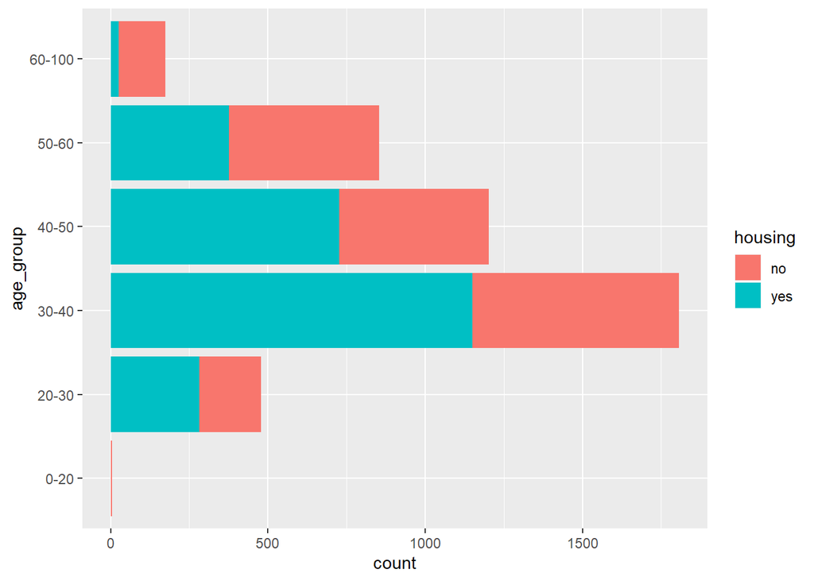

```r
bank <- mutate(bank, age_group = case_when(
  age < 20 ~ "0-20",
  age < 30 ~ "20-30",
  age < 40 ~ "30-40",
  age < 50 ~ "40-50",
  age < 60 ~ "50-60",
  age >= 60 ~ "60-100"
))
ggplot(bank,aes(age_group))+
  geom_bar(aes(fill=housing))+
  coord_flip()
```

*We can observe that people tend to have their own house when they are at their working ages.* However, it is hard to know why people above 60s have the least proportion of housing. *Maybe it is because they have already retired, they sold their houses for some reason such as traveling.

#Finding3

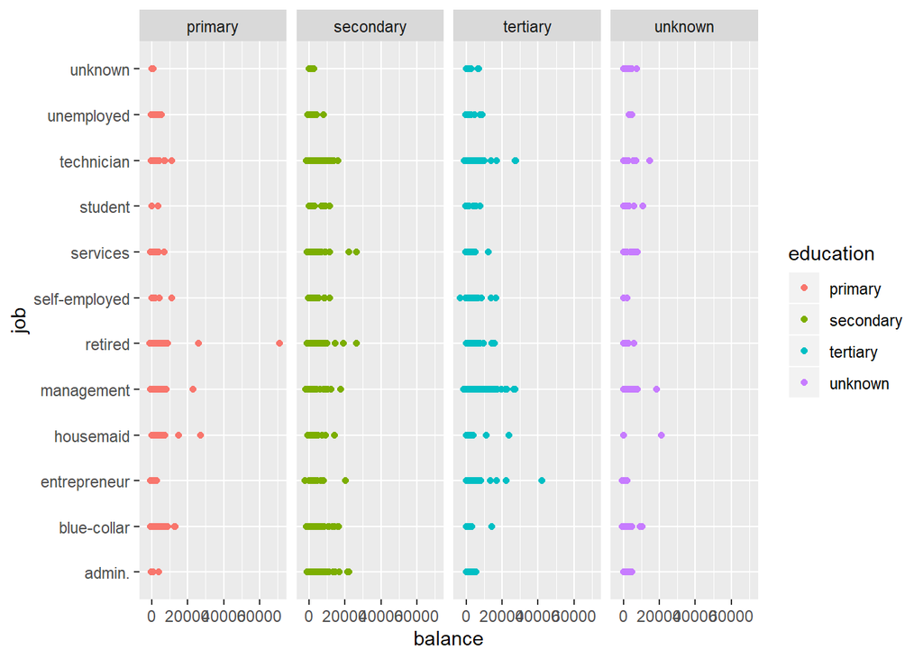

```r
ggplot(bank, aes(balance, job))+
  geom_point(aes(color = education))+
  facet_grid(. ~ education)
```

*Most of the jobs tend to have a higher pay if you have a higher education.

#Finding4

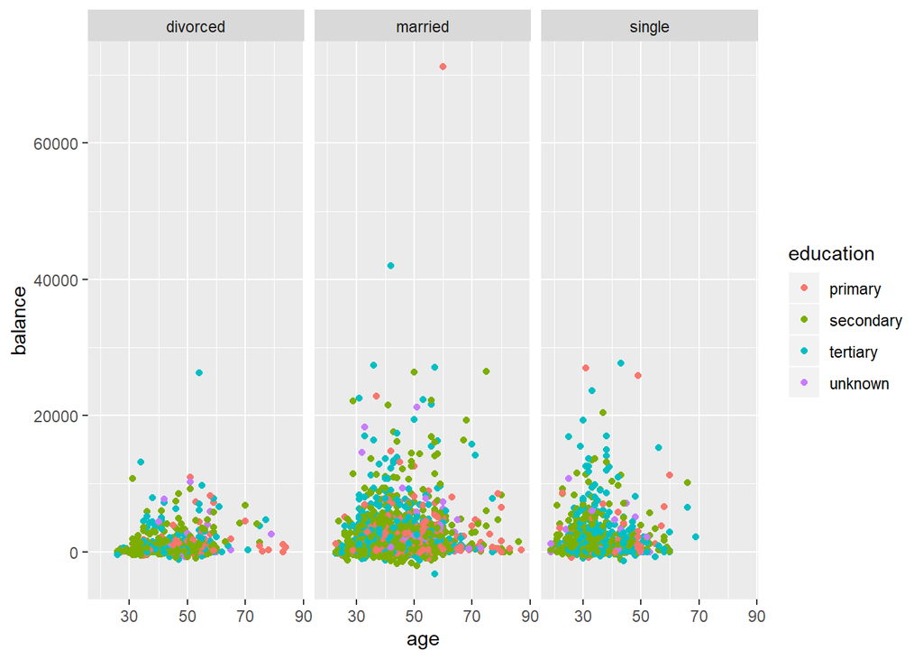

```r
ggplot(bank)+
  geom_point(aes(x=age, y=balance, color = education))+
  facet_wrap(~ marital, nrow =1)
```

*First, people who are married or single have a higher balance than people who are divorced. I think it is maybe divorced people have some extra payments to thier original family or some law suits to pay.* Second, compared to divorced and married people, there is very few single people when they are above 70s.

#Finding5

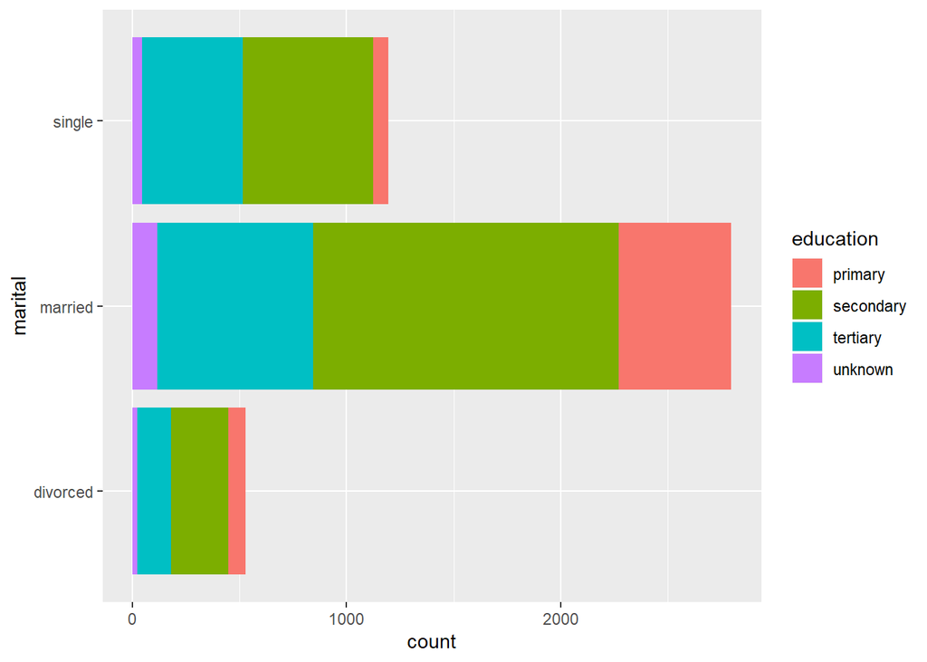

```r
ggplot(bank,aes(marital))+
  geom_bar(aes(fill=education))+
  coord_flip()
```

*We can see from these bars that the total married people are 2 times more than the total single people.* However, look at the proportion of the higher education. *If you have a higher education, you will more likely to be single.* That is intriguing…

#Finding6

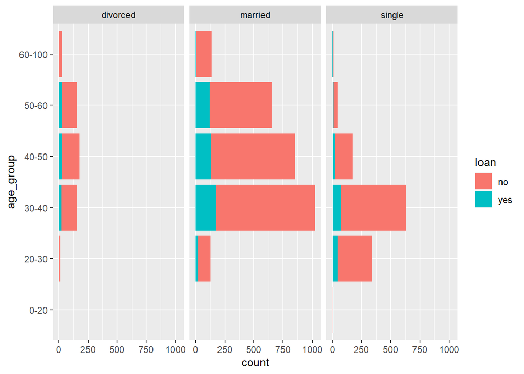

```r
ggplot(bank,aes(age_group))+
  geom_bar(aes(fill=loan))+
  coord_flip()+
  facet_wrap(~ marital, nrow =1)
```

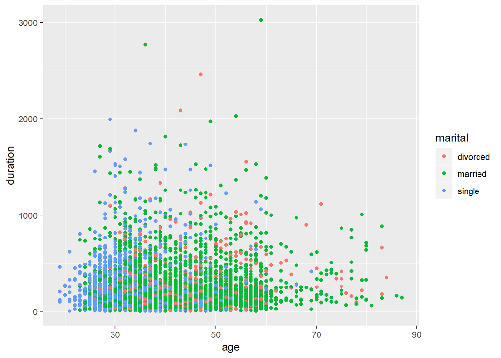

```r
ggplot(bank) +
geom_point(aes(age, duration, color = marital, group = marital))
```

*Most of the plots with a higher duration which is above 1000 are from married and single people.

#Finding8

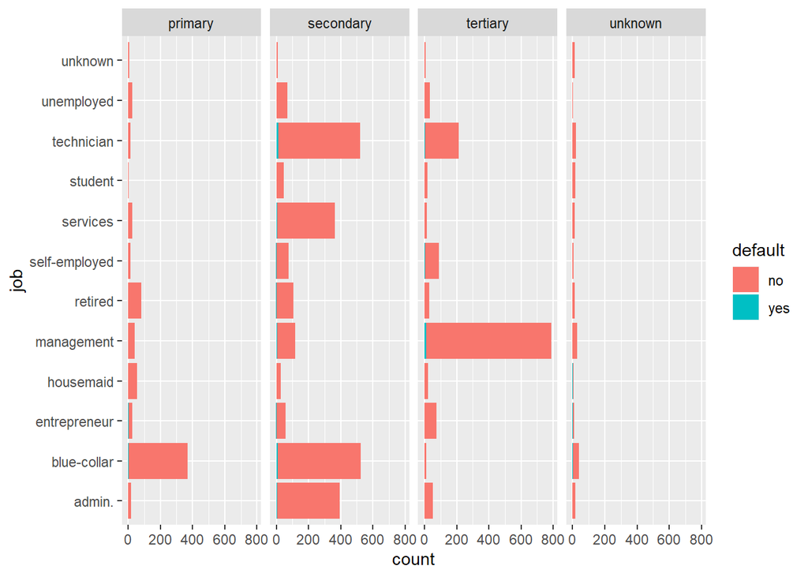

```r
ggplot(bank,aes(job))+
  geom_bar(aes(fill = default))+
  coord_flip()+
  facet_wrap(~ education, nrow =1)
```

*From these 4 bars, we can observe 2 phenomenona.* 1st, if you have a higher education, you will probably to have a management position or to be an entrepreneur in your job. That means it is worth having a higher education. *2nd, similarly, people have a higher education, they tend to have a less possibility to default.

#Finding9

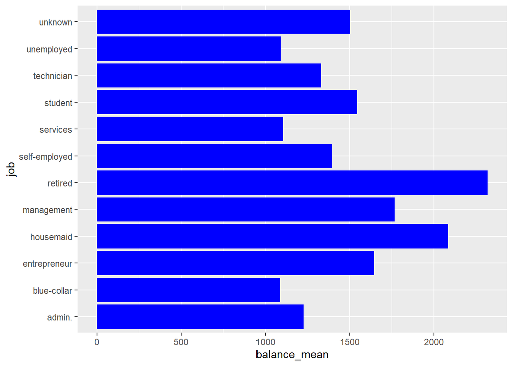

```r
df1 <- group_by(bank, job) %>%
  summarise(balance_mean = mean(balance))%>%
  arrange(balance_mean)
df2 <- group_by(bank, job) %>%
  summarise(balance_max = max(balance))%>%
  arrange(balance_max)

df3 <- left_join(df1,df2, by = "job")

ggplot(df3, aes(x=job, y=balance_mean))+
  geom_bar(stat = "identity", fill = "blue")+
  coord_flip()
```

#Finding10

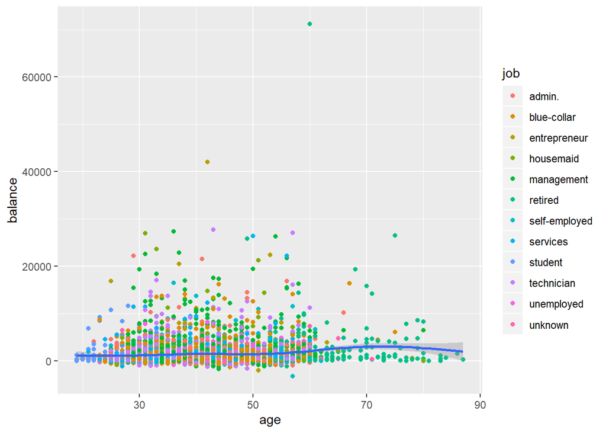

```r
ggplot(bank, aes(age, balance)) + geom_point(aes(color = job)) +
geom_smooth()
```

*This graph combines most of the things we found before.* On the right hand side(age >60) of the graph, people are most retired. *People tend to have a higher balance is they are management positions or entreperneur positions.* Obviously, plots on the left hand side are most students.